# Airbnb Listing Price Prediction & Neighbourhood Segmentation

# 9 Model Explainability using LIME

While Random Forest delivers superior accuracy, ensemble decision trees are complex and non-transparent. To provide listing-level accountability, we deploy **LIME** (Local Interpretable Model-agnostic Explanations; Ribeiro et al., 2016).

### 9.0.1 Methodological Foundation & S3 Compatibility

LIME approximates the black-box model locally around a specific observation $x$ by perturbing feature values, obtaining black-box predictions for the perturbed instances, weighting instances by proximity to $x$, and fitting a sparse, interpretable ridge regressor.

In current versions of the R `lime` package, S3 dispatch methods for regression models of class `randomForest` must be registered explicitly:

```r
# Register custom S3 methods for randomForest regression in lime
model_type.randomForest <- function(x, ...) {
  return("regression")
}

predict_model.randomForest <- function(x, newdata, type, ...) {
  res <- predict(x, newdata = newdata)
  return(data.frame(Response = as.numeric(res)))
}
```

### 9.0.2 Explaining a Real Test-Set Listing

We examine the first observation in our held-out test partition:

```r
# Build explainer on training data
set.seed(123)
explainer <- lime(
  x = train_set %>% select(-price),
  model = rf_model,
  bin_continuous = TRUE,
  n_bins = 5
)

# Extract test listing 1
target_case <- test_set[1, ] %>% select(-price)
actual_price <- test_set$price[1]
predicted_price <- predict(rf_model, newdata = target_case)

# Generate local explanation using lime::explain to prevent dplyr masking
explanation <- lime::explain(
  x = target_case,
  explainer = explainer,
  n_features = 8
)
```

```r
case_summary <- tibble(
  Attribute = names(target_case),
  Value = as.character(unlist(target_case[1, ]))
)
kable(case_summary, caption = paste0("Test Listing #1 Profile (Actual Price: $", actual_price, " | Predicted Price: $", round(predicted_price, 2), ")"))
```

Test Listing #1 Profile (Actual Price: $89 | Predicted Price: $91.01)

| Attribute | Value |
| --- | --- |
| room_type | 2 |
| neighbourhood_group | 2 |
| latitude | 40.66829 |
| longitude | -73.98779 |
| minimum_nights | 4 |
| number_of_reviews | 167 |
| reviews_per_month | 1.34 |
| calculated_host_listings_count | 3 |
| availability_365 | 314 |

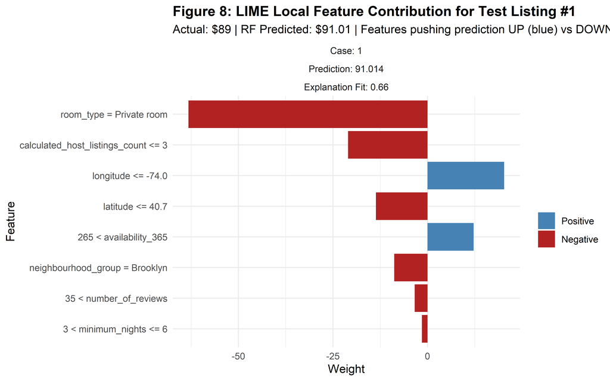

```r
plot_features(explanation) +
  labs(
    title = "Figure 8: LIME Local Feature Contribution for Test Listing #1",
    subtitle = sprintf("Actual: $%.0f | RF Predicted: $%.2f | Features pushing prediction UP (blue) vs DOWN (red)",
                       actual_price, predicted_price)
  ) +
  theme_minimal(base_size = 11) +
  theme(plot.title = element_text(face = "bold"))
```

### 9.0.3 Detailed Interpretation of LIME Explanation

- **Listing Context**: The explained listing is a `Private room` in `Brooklyn` with a 4-night minimum, 167 total reviews (1.34 reviews/month), host managing 3 listings, and high calendar availability (314 days/year).
- **Prediction Accuracy**: The Random Forest predicted **$91.01**, which is remarkably close to the actual market rate of **$89.00** (an error of just $2.01).
- **Feature Weights**:
  1. `room_type = Private room` exerts the single largest downward push (**$-\$63.30$**). Offering a private room rather than an entire home suppresses the valuation substantially.
  2. `longitude <= -74.0` provides a notable positive push (**$+\$21.80$**). The property is located at longitude $-73.988$ (near Gowanus/Park Slope), situating it close to prime downtown Brooklyn and Lower Manhattan transit lines.
  3. `availability_365 > 265` exerts a positive influence (**$+\$11.90$**), as commercial year-round availability is associated with higher listing rates.
  4. `neighbourhood_group = Brooklyn` has a mild negative contribution (**$-\$8.93$**) compared to a Manhattan baseline.
- **Epistemological Caution**: LIME provides a **local linear surrogate approximation** of the model’s response surface in the immediate vicinity of this listing. It explains *how the model made this specific prediction*; it **does not establish real-world causality** (e.g., artificially reducing host listing count will not causally change property value).

# 10 Neighbourhood Segmentation using K-Means

Having modeled listing-level pricing, we shift to unsupervised learning to uncover structural geographic tiers across New York City.

### 10.0.1 Aggregation & Feature Engineering

We aggregate listings by neighbourhood, retaining the 115 neighbourhoods with at least **30 listings** to ensure statistically robust aggregate estimates: - `median_price`: Robust measure of typical accommodation cost. - `mean_price`: Captures upper-tail pricing skew within the neighbourhood. - `listing_count`: Measures listing density and market supply. - `prop_entire_home`: Proportion of entire home listings, serving as the neighbourhood-level accommodation capacity and privacy proxy. - `avg_min_nights`: Average minimum stay requirement (short-term vs. extended stay orientation). - `avg_reviews`: Average review volume, measuring turnover and booking frequency. - `avg_availability`: Average annual calendar availability, indicating commercial vs. casual host orientation.

```r
neigh_summary <- clean_data %>%
  group_by(neighbourhood) %>%
  summarise(
    median_price     = median(price),
    mean_price       = mean(price),
    listing_count    = n(),
    prop_entire_home = mean(room_type == "Entire home/apt"),
    avg_min_nights   = mean(minimum_nights),
    avg_reviews      = mean(number_of_reviews),
    avg_availability = mean(availability_365),
    .groups = "drop"
  ) %>%
  filter(listing_count >= 30) %>%
  column_to_rownames("neighbourhood")

cat("Number of qualified neighbourhoods (>= 30 listings):", nrow(neigh_summary), "\n")
```

```
## Number of qualified neighbourhoods (>= 30 listings): 115
```

### 10.0.2 Standardizing Features & Selecting $k$ via Elbow Method

Because variables possess vastly different units and scales (e.g., listing counts in the thousands vs. proportions between 0 and 1), we apply $z$-score standardization ($\mu = 0, \sigma = 1$) prior to Euclidean distance computation.

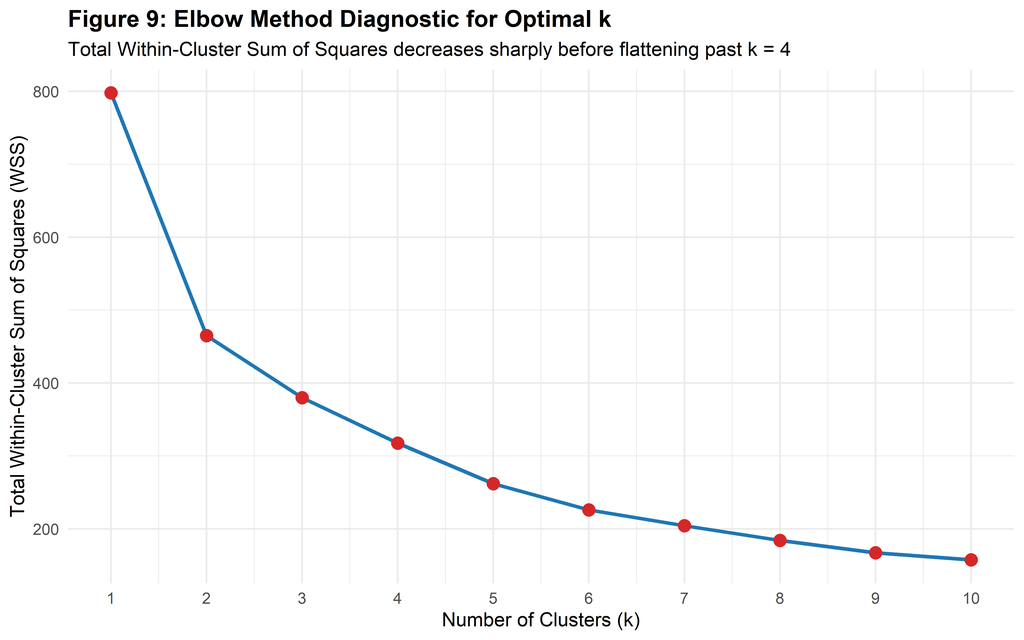

```r
neigh_scaled <- scale(neigh_summary)

set.seed(123)
wss_values <- sapply(1:10, function(k) {
  kmeans(neigh_scaled, centers = k, nstart = 25)$tot.withinss
})

elbow_df <- tibble(k = 1:10, WSS = wss_values)

ggplot(elbow_df, aes(x = k, y = WSS)) +
  geom_line(color = "#1f77b4", linewidth = 1) +
  geom_point(color = "#d62728", size = 3) +
  scale_x_continuous(breaks = 1:10) +
  labs(
    title = "Figure 9: Elbow Method Diagnostic for Optimal k",
    subtitle = "Total Within-Cluster Sum of Squares decreases sharply before flattening past k = 4",
    x = "Number of Clusters (k)",
    y = "Total Within-Cluster Sum of Squares (WSS)"
  ) +
  theme_minimal(base_size = 11) +
  theme(plot.title = element_text(face = "bold"))
```

**Diagnostic Analysis**: Total WSS drops sharply from $k=1$ (798.0) to $k=2$ (465.2), $k=3$ (380.0), and $k=4$ (317.4). Beyond $k=4$, marginal variance explained diminishes smoothly ($k=5$ WSS is 262.0), making **$k = 4$** a parsimonious and natural elbow threshold.

### 10.0.3 Executing K-Means Clustering ($k = 4$)

```r
set.seed(123)
k_chosen <- 4
km_result <- kmeans(neigh_scaled, centers = k_chosen, nstart = 25)

neigh_summary$cluster <- as.factor(km_result$cluster)
```

### 10.0.4 Empirical Cluster Profiles

```r
profiles <- neigh_summary %>%
  group_by(cluster) %>%
  summarise(
    Neighbourhoods    = n(),
    Median_Price      = mean(median_price),
    Mean_Price        = mean(mean_price),
    Avg_Listings      = mean(listing_count),
    Pct_Entire_Home   = round(100 * mean(prop_entire_home), 1),
    Avg_Min_Nights    = mean(avg_min_nights),
    Avg_Reviews       = mean(avg_reviews),
    Avg_Availability  = mean(avg_availability)
  )

kable(profiles, digits = 1, caption = "Empirical Cluster Centroid Profiles (k = 4)")
```

Empirical Cluster Centroid Profiles (k = 4)

| cluster | Neighbourhoods | Median_Price | Mean_Price | Avg_Listings | Pct_Entire_Home | Avg_Min_Nights | Avg_Reviews | Avg_Availability |
| --- | --- | --- | --- | --- | --- | --- | --- | --- |
| 1 | 4 | 82.8 | 100.4 | 3096.2 | 38.2 | 6.0 | 25.6 | 96.3 |
| 2 | 42 | 74.8 | 87.4 | 267.5 | 36.6 | 5.7 | 21.1 | 126.8 |
| 3 | 28 | 70.9 | 85.6 | 91.7 | 38.6 | 3.3 | 37.3 | 187.1 |
| 4 | 41 | 150.7 | 156.1 | 453.7 | 66.9 | 8.7 | 21.7 | 97.5 |

### 10.0.5 Visualizing Clusters

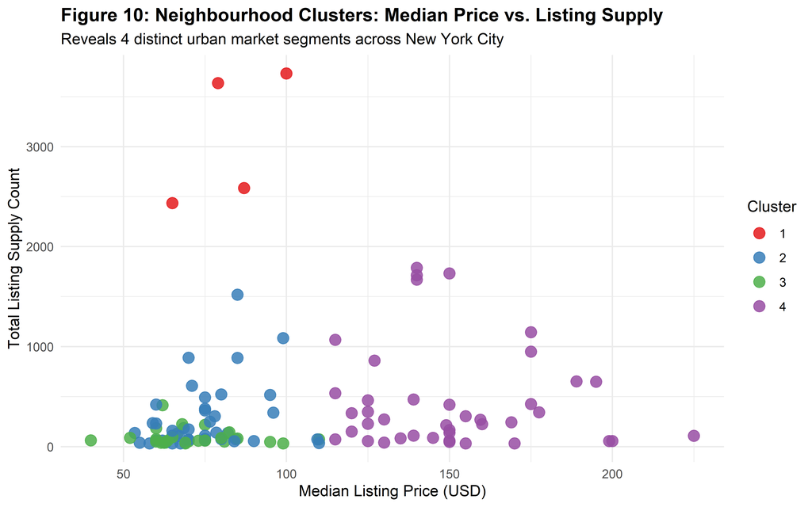

```r
ggplot(neigh_summary, aes(x = median_price, y = listing_count, color = cluster)) +
  geom_point(size = 3.5, alpha = 0.85) +
  scale_color_brewer(palette = "Set1", name = "Cluster") +
  labs(
    title = "Figure 10: Neighbourhood Clusters: Median Price vs. Listing Supply",
    subtitle = "Reveals 4 distinct urban market segments across New York City",
    x = "Median Listing Price (USD)",
    y = "Total Listing Supply Count"
  ) +
  theme_minimal(base_size = 11) +
  theme(plot.title = element_text(face = "bold"))
```

### 10.0.6 Interpretation of Empirical Cluster Segments

Rather than imposing preconceived labels, we characterize the clusters directly from their centroid data:

1. **Cluster 1 (Mega-Volume Cultural & Tourist Hubs; $n = 4$)**:
   - **Neighbourhoods**: *Bedford-Stuyvesant, Bushwick, Harlem, Williamsburg*.
   - **Characteristics**: Enormous listing density (averaging **3,096 listings** per neighbourhood), moderate median price (**$82.8**), lower proportion of entire homes (**38.2%**, predominantly private rooms for young travelers and students), and moderate stays (6.0 nights). These represent NYC’s primary volume epicenters.
2. **Cluster 2 (Moderate-Density Residential Outer Boroughs; $n = 42$)**:
   - **Neighbourhoods**: *Astoria, Bay Ridge, Bensonhurst, Brighton Beach, Crown Heights, Jackson Heights, Sunset Park…*
   - **Characteristics**: Moderate listing count (**267.5**), accessible median price (**$74.8**), lower entire-home share (**36.6%**), and modest availability (126.8 days). These are authentic residential communities serving value-conscious long-stay visitors.
3. **Cluster 3 (Low-Density, High-Turnover Suburban & Transit Gateways; $n = 28$)**:
   - **Neighbourhoods**: *Allerton, Arverne, Bayside, Briarwood, Canarsie, Concourse, Jamaica, Flushing…*
   - **Characteristics**: Low listing density (**91.7**), lowest median price (**$70.9**), shortest minimum stays (**3.3 nights**), highest lifetime review turnover (**37.3 reviews**), and highest year-round calendar availability (**187.1 days**). Many cluster around JFK/LaGuardia airports or transit hubs, catering to short-stay travelers.
4. **Cluster 4 (Premium Commercial Manhattan & Waterfront Brooklyn Core; $n = 41$)**:
   - **Neighbourhoods**: *Chelsea, Chinatown, Financial District, Greenwich Village, Midtown, SoHo, Tribeca, West Village, Brooklyn Heights, DUMBO…*
   - **Characteristics**: Highest median price (**$150.7**) and mean price (**$156.1**), high density (**453.7**), dominated by entire apartments (**66.9% entire home/apt**), and longest minimum stay policies (**8.7 nights**). This represents the luxury, high-capacity urban core.